# Self-Organized Criticality

```python
#@title imports
%tensorflow_version 2.x

import math
import tqdm
import random

import numpy as np
import pandas as pd
import matplotlib.pyplot as plt
import seaborn as sns

!pip install -q tsalib
import tsalib
import networkx
!pip install -q jplotlib
import jplotlib as jpl
!pip install -q livelossplot
from livelossplot import PlotLossesKeras
!pip install -q powerlaw
import powerlaw

import tensorflow as tf
keras = tf.keras
tfkl = keras.layers

import tensorflow_probability as tfp
tfd = tfp.distributions
tfpl = tfp.layers
tfb = tfp.bijectors
```

```python
#@title utils

def Bernoulli(p, shape=None):
    return tf.cast(tf.random.uniform(shape) < p, tf.float32)

def clear_diag(A):
    return A * (1 - tf.eye(tf.shape(A)[-2], tf.shape(A)[-1]))

def TODO(reason=""):
    raise NotImplementedError("TODO: " + reason)
```

## [Self-organized criticality in neural networks from activity-based-rewiring](https://arxiv.org/abs/2009.1178)

Let $N=( \mathbf{a}, \mathbf{\bar{a}}, C )$ be a $n$-node network where

- $\mathbf{a} = a_{1,2,\dots,n} \in [0,1]^{b \times n}$ are its node states
- $\mathbf{\bar{a}} = \bar{a}_{1,2,\dots,n} \in [0,1]^{b \times n}$ are its mean node states
- $C = \{c_{ij}\} \in [-1, 1]^{n \times n}$ is its connectivity matrix from node $i$ to node $j$

At every time step:

Parameters:

- $n =$ number neurons
- $b =$ batch size
- $\beta \in (0, \infty) =$ inverse temperature. Higher values decrease entropy.
- $P =$ the Bernoilli distribution
- $\epsilon =$ update threshold
- $\alpha \in [0, 1] =$ mean activation update window

### `update` function

```python
p = params = dict(n=32, b=1, beta=2, epsilon=0.2, alpha=0.1)

def update(inputs):
    a, a_ave, C = inputs

    a = tfp.distributions.Bernoulli(logits=p['beta'] * (a @ C)).sample()
    a = tf.cast(a, tf.float32)

    a_ave = p['alpha'] * a + (1 - p['alpha']) * a_ave

    js = tf.random.uniform(shape=(p['b'],), minval=0, maxval=p['n'], dtype=tf.int32) # dest nodes
    ks = tf.random.uniform(shape=(p['b'],), minval=0, maxval=p['n'], dtype=tf.int32) # src nodes

    for b in tf.range(p['b']):
        j = js[b]
        k = ks[b]

        if a_ave[b, j] > +1 - p['epsilon']:
            C[k,j].assign(-1.0)
        elif a_ave[b, j] < p['epsilon']:
            C[k,j].assign(+1.0)
        else:
            C[k,j].assign(0.0)

    return (a, a_ave, C)

def loop(data, duration=1000):
    for _ in tf.range(duration):
        data = update(data)
    return data
```

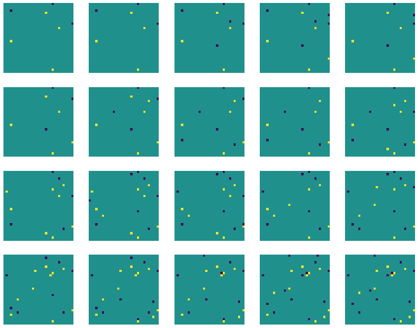

```python
a = tf.zeros((params['b'], params['n']))
a_ave = tf.zeros((params['b'], params['n']))
C = tf.zeros((params['n'], params['n']))
C = tf.Variable(C)
#C = tf.random.uniform((params['n'], params['n']), minval=-1.0, maxval=1.0)
states = (a, a_ave, C)

T_step = 100
N = 20

N_col = 5
N_row = math.ceil(N / N_col)
fig, axes = plt.subplots(nrows=N_row, ncols=N_col, figsize=(3*N_col, 3*N_row))

for n in tqdm.tqdm(range(N)):
    a, a_ave, C = loop((a, a_ave, C), duration=T_step)

    col = n % N_col
    row = n // N_col
    axes[row, col].axis('off')
    axes[row, col].imshow(C)

plt.show()
```

### keras layer

```python
class CriticalLayer0(tfkl.Layer):

    DEFAULT_PARAMS = dict(
        n=None,
        b=None,
        beta=2,
        epsilon=0.2,
        alpha=0.1,
        steps_update=10)

    def __init__(self, p=None, **kwargs):
        super(CriticalLayer0, self).__init__(**kwargs)

        if p is None:
            p = dict()
        self.p = CriticalLayer0.DEFAULT_PARAMS
        self.p.update(p)

    def build(self, input_shape):
        self.p['b'], self.p['n'] = input_shape.as_list()

        self.a_ave = tf.zeros((self.p['b'], self.p['n']), dtype=tf.float32)
        self.C = tf.random.uniform((self.p['n'], self.p['n']), dtype=tf.float32)
        self.C = tf.Variable(self.C)

    def call(self, inputs):
        a = inputs
        for _ in tf.range(self.p['steps_update']):
            a = self._single_update(a)
        return a

    def _single_update(self, a):
        a = self.p['beta'] * (a @ self.C)
        a = tfd.Bernoulli(logits=a).sample()
        a = tf.cast(a, tf.float32)

        self.a_ave = self.p['alpha'] * a + (1 - self.p['alpha']) * self.a_ave

        js = tf.random.uniform(shape=(self.p['b'],),
                               minval=0, maxval=self.p['n'],
                               dtype=tf.int32) # dest nodes
        ks = tf.random.uniform(shape=(self.p['b'],),
                               minval=0, maxval=self.p['n'],
                               dtype=tf.int32) # src nodes

        for b in tf.range(self.p['b']):
            j = js[b]
            k = ks[b]

            if self.a_ave[b, j] > +1 - self.p['epsilon']:
                self.C[k,j].assign(-1.0)
            elif self.a_ave[b, j] < self.p['epsilon']:
                self.C[k,j].assign(+1.0)
            else:
                self.C[k,j].assign(0.0)

        return a
```

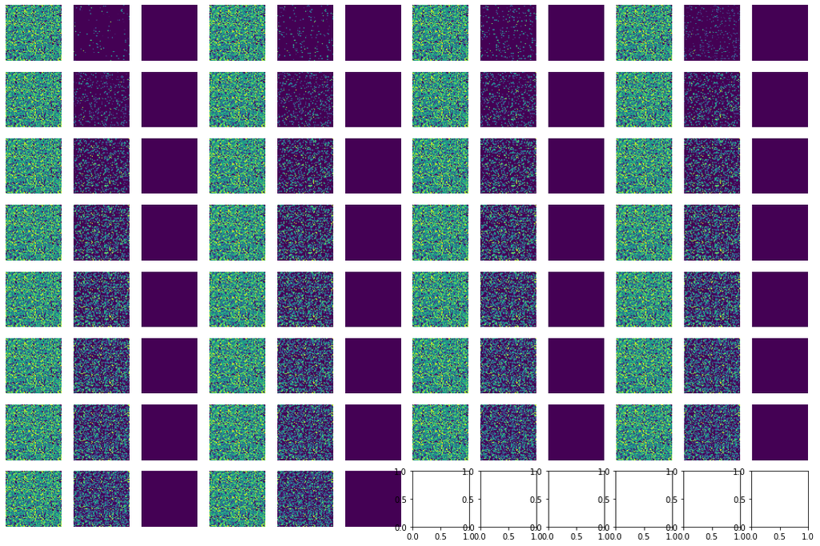

```python
layer = CriticalLayer0(dict(
        beta=0.5,
        epsilon=0.1,
        alpha=0.005,
        steps_update=100))
a = tf.zeros((1, 64))

a = layer(a)
C_orig = layer.C.numpy()

with jpl.GridPlot(ncols=12, width=18) as grid_plot:
    for _ in range(30):
        a = layer(a)

        grid_plot.imshow(layer.C)
        C_diff = C_orig - layer.C
        grid_plot.imshow(tf.nn.relu(C_diff))
        grid_plot.imshow(tf.nn.relu(-C_diff))
```

## [Criticality meets learning: Criticality signatures in a self-organizing recurrent neural network](https://journals.plos.org/plosone/article?id=10.1371/journal.pone.0178683)

The self-organizing recurrent network (SORN) consists of excitatory $x\in\mathbb{R}^{N_E}$ and inhibitory $y\in\mathbb{R}^{N_I}$ neurons ($N_I = 0.2 \times N_E$) connected in a system of boolean update equations with fast and slow acting responses

- excitatory to excitatory connections $W^{EE} \in \mathbb{R}^{N_E \times N_E}$; $w^{EE}_{ij} \sim \mathcal{B}(p=0.1)\mathcal{U}(0, s^2=0.1)$ without self-connections $w^{EE}_{ij}=0 \Leftrightarrow i=j$
- inhibitory to excitatory connections $W^{EI} \in \mathbb{R}^{N_E \times N_I}$; $w^{EI}_{ij} \sim \mathcal{B}(p=0.2)\mathcal{U}(0, s^2=0.1)$ without self-connections $w^{EI}_{ij}=0 \Leftrightarrow i=j$
- excitatory to inhibitory connections $W^{IE} \in \mathbb{R}^{N_I \times N_E}$; $w^{IE}_{ij} \sim \mathcal{U}(0, s^2=0.1)$ without self-connections $w^{IE}_{ij}=0 \Leftrightarrow i=j$
- input noise $\zeta^{E/I} \sim \mathcal{N}(\mu=0, \sigma^2=0.05)$
- external input $u^{ext}(t) = 0\ \mathrm{(default)}$
- excitatory and inhibitory activation thresholds $T^{E/I} \in \mathbb{R}^{N_E/N_I}$; $T^E \sim \mathcal{U}(0, T^E_{max}=0.5)$, $T^I \sim \mathcal{U}(0, T^I_{max}=1.0)$

```python
#@title architecture params

architecture_params = dict(
    N_E = 200,
    N_I = int(0.2 * 200),
)
```

### Fast Dynamics

```python
#@title init fast dynamics params
def heaveside_step_fn(x):
    return tf.cast(x > 0, tf.float32)

fast_params = dict(
    activation_fn = heaveside_step_fn,
    T_E_max = 0.5,
    T_I_max = 1.0,
    constant_T_E = None,
    constant_T_I = None,
    zeta_E_mu = 0.0,
    zeta_E_s2 = 0.05,
    zeta_I_mu = 0.0,
    zeta_I_s2 = 0.05,
    W_EE_p = 0.1,
    W_EE_s2 = 0.1,
    W_EI_p = 0.2,
    W_EI_s2 = 0.1,
    W_IE_p = 1.0,
    W_IE_s2 = 0.1,
    u_ext = 0,
)

def init_fast_params(p):

    if 'N_I' not in p:
        p['N_I'] = 0.2 * p['N_E']
    N_E, N_I = p['N_E'], p['N_I']

    p.update(dict(
        T_E = p['constant_T_E'] if p['constant_T_E'] else
                tf.random.uniform(shape=(N_E, 1), minval=0,
                                  maxval=p['T_E_max']),
        T_I = p['constant_T_I'] if p['constant_T_I'] else
                tf.random.uniform(shape=(N_I, 1), minval=0,
                                  maxval=p['T_I_max']),
        W_EE = Bernoulli(p=p['W_EE_p'], shape=(N_E, N_E))
               * tf.random.normal(shape=(N_E, N_E), mean=0.0,
                                  stddev=p['W_EE_s2'] ** 0.5),
        W_EI = Bernoulli(p=p['W_EI_p'], shape=(N_E, N_I))
               * tf.random.normal(shape=(N_E, N_I), mean=0.0,
                                  stddev=p['W_EI_s2'] ** 0.5),
        W_IE = Bernoulli(p=p['W_IE_p'], shape=(N_I, N_E))
               * tf.random.normal(shape=(N_I, N_E), mean=0.0,
                                  stddev=p['W_IE_s2'] ** 0.5),
        x = tf.zeros((N_E, 1)),
        y = tf.zeros((N_I, 1)),
        x_prev = tf.zeros((N_E, 1)),
        y_prev = tf.zeros((N_I, 1)),
    ))

    return p
```

Fast-acting behavior affects both excitatory $x$ and inhibitory $y$ neurons by

$$x(t+1) = \Theta \biggl [ W^{EE}(t)x(t) - W^{EI}(t)y(t) + u^{ext}(t) + \xi^E(t) - T^E(t) \biggr ]$$

$$y(t+1) = \Theta \biggl [ W^{IE}(t)x(t) + \xi^I(t) - T^I(t) \biggr ]$$

```python
def fast_update(p):

    p['x_prev'] = p['x']
    p['y_prev'] = p['y']

    zeta_E = tf.random.normal(shape=(p['N_E'], 1),
                              mean=p['zeta_E_mu'],
                              stddev=p['zeta_E_s2'] ** 0.5)
    zeta_I = tf.random.normal(shape=(p['N_I'], 1),
                              mean=p['zeta_I_mu'],
                              stddev=p['zeta_I_s2'] ** 0.5)

    p['x'] = p['activation_fn'](p['W_EE'] @ p['x_prev']
                                - p['W_EI'] @ p['y_prev']
                                + p['u_ext'][:, None]
                                + zeta_E
                                - p['T_E'])
    p['y'] = p['activation_fn'](p['W_IE'] @ p['x_prev']
                                + zeta_I
                                - p['T_I'])

    return p
```

### Slow Adaptations

```python
#@title init slow adaptation params
#@markdown "Assuming one time step equals 10 to 20 ms, these constants resulted in an average firing rate in the 5 − 10 Hz range." (Papa 2017)
slow_params = dict(
    eta_STDP = 0.004,
    eta_inh = 0.001,
    eta_SP = 0.001,
    p_SP_0 = 0.1,
    mu_IP = 0.1,
    s2_IP = 0.0, # "for simplicity, it could be set to the network average
                 #  firing rate μIP, thus being equal for all neurons"
    eta_IP = 0.01,
)

def init_slow_params(p):

    p.update(dict(
        H_IP = tf.random.normal(shape=(p['N_E'],),
                                mean=p['mu_IP'],
                                stddev=p['s2_IP']),
        p_SP = (p['N_E']*((p['N_E']-1)) /
                (200*(200-1))) * p['p_SP_0'],
    ))
    del p['p_SP_0']

    return p
```

1. **Spike Timing Dependant Plasticity (STDP)** makes synapse $w^{EE}_{ij}$ decrease when $i$ activates before $j$ (since the connection must've not been important) and increase when $i$ activate after $j$ (since the connection made a significant contribution). It has no effect when one of the values is $0$: $$\Delta w^{EE}_{ij} = \eta_{STDP}[x_i(t)x_j(t-1) - x_j(t)x_i(t-1)]$$

```python
def STDP(p):

    p['W_EE'] = p['W_EE'] + p['eta_STDP'] * (
                    p['x'] * tf.transpose(p['x_prev'])
                    -tf.transpose(p['x']) * p['x_prev'])

    return p
```

```python
def iSTDP(p):

    p['W_EI'] = p['W_EI'] + p['eta_inh'] * tf.transpose(p['y_prev']) * \
                    (1 - p['x'] * (1 + 1/p['mu_IP']))

    return p
```

3. **Synaptic normalization** normalizes input for $W^{EE}$ and $W^{EI}$ to $1$: $$W^{EE/EI}_{ij} \leftarrow W^{EE/EI}_{ij} / \sum_j W^{EE/EI}_{ij}$$

```python
def synaptic_normalization(p):

    p['W_EE'] = p['W_EE'] / (tf.reduce_sum(p['W_EE'], axis=-1, keepdims=True) + 1e-3)
    p['W_EI'] = p['W_EI'] / (tf.reduce_sum(p['W_EI'], axis=-1, keepdims=True) + 1e-3)

    return p
```

4. **Structural Plasticity (SP)** randomly adds small values synapses ($\eta_{SP}=0.001$) between unconnected neurons by Bernoili probability factor $p_{SP}$ which scales quatratically with respect to the number of nodes $p_{SP}(N^E) = \frac{N^E(N^E-1)}{200(199)}p_{SP}(N^E=200)$ with the base case $p_{SP}(N^E=200) = 0.1$. $$w^{EE/EI}_{ij} \leftarrow \eta_{SP}\mathcal{B}(p_{SP}) \Leftrightarrow w^{EE/EI}_{ij} = 0$$

```python
def structural_plasticity(p):

    no_W_EE_synapses_mask = tf.cast(p['W_EE'] == 0, tf.float32)
    new_W_EE_synapses = p['eta_SP'] * Bernoulli(p['p_SP'], shape=p['W_EE'].shape)
    p['W_EE'] = p['W_EE'] + no_W_EE_synapses_mask * new_W_EE_synapses

    no_W_EI_synapses_mask = tf.cast(p['W_EI'] == 0, tf.float32)
    new_W_EI_synapses = p['eta_SP'] * Bernoulli(p['p_SP'], shape=p['W_EI'].shape)
    p['W_EI'] = p['W_EI'] + no_W_EI_synapses_mask * new_W_EI_synapses

    return p
```

5. **Intrinsic plasticity (IP)** homeostatically adapts excitatory firing thresholds to maintain a mean firing rate $H_{IP} \sim \mathcal{N}(\mu_{IP}=0.1, \sigma_{IP}^2 = 0)$ $$\Delta T^{E} = \eta_{IP}[x(t) - H_{IP}]$$

```python
def intrinsic_plasticity(p):

    p['T_E'] = p['T_E'] + p['eta_IP'] * (p['x'] - p['H_IP'][:, None])

    return p
```

Negative ($x<0$), large ($x>1$), and null weights are pruned after each update step. Also remove any self connections that may have been formed

```python
def slow_adaptation(p):

    p = STDP(p)
    p = iSTDP(p)
    p = synaptic_normalization(p)
    p = structural_plasticity(p)
    p = intrinsic_plasticity(p)

    p['W_EE'] = tf.clip_by_value(p['W_EE'], 0.0, 1.0)
    p['W_EI'] = tf.clip_by_value(p['W_EI'], 0.0, 1.0)
    p['W_IE'] = tf.clip_by_value(p['W_IE'], 0.0, 1.0)

    p['W_EE'] = clear_diag(p['W_EE'])
    p['W_EI'] = clear_diag(p['W_EI'])
    p['W_IE'] = clear_diag(p['W_IE'])

    return p
```

### Putting it all together

```python
class SORN:

    DEFAULT_ARCHITECTURE_PARAMS = architecture_params
    DEFAULT_FAST_PARAMS = fast_params
    DEFAULT_SLOW_PARAMS = slow_params

    def __init__(self, params=None):

        self.params = dict()
        self.params.update(SORN.DEFAULT_ARCHITECTURE_PARAMS)
        self.params.update(SORN.DEFAULT_FAST_PARAMS)
        self.params.update(SORN.DEFAULT_SLOW_PARAMS)
        if params:
            self.params.update(params)
        self.params = init_fast_params(self.params)
        self.params = init_slow_params(self.params)


    def __call__(self, inputs=None, T=None, logging_fn=None):
        """simulate SORN on an external input tensor shaped (T, N_E)
        or zero external input for T timesteps."""

        if inputs is None and T is not None:
            inputs = tf.zeros((T, self.params['N_E']))

        for input in tf.unstack(inputs, axis=0):
            self.params['u_ext'] = input
            self.params = fast_update(self.params)
            self.params = slow_adaptation(self.params)

            if logging_fn:
                logging_fn(self.params)
```

### Experiments

```python
#@title plotting utilities

class Logger:

    def __init__(self, T, N_E, N_I):
        self.xs = tf.zeros((1, N_E))
        self.ys = tf.zeros((1, N_I))
        self.W_EEs = tf.zeros((1, N_E, N_E))
        self.W_EIs = tf.zeros((1, N_E, N_I))
        self.W_IEs = tf.zeros((1, N_I, N_E))


    def logging_fn(self, params):
        self.xs = tf.concat([self.xs, params['x'][None, ..., 0]], axis=0)
        self.ys = tf.concat([self.ys, params['y'][None, ..., 0]], axis=0)
        self.W_EEs = tf.concat([self.W_EEs, params['W_EE'][None, ...]], axis=0)
        self.W_EIs = tf.concat([self.W_EIs, params['W_EI'][None, ...]], axis=0)
        self.W_IEs = tf.concat([self.W_IEs, params['W_IE'][None, ...]], axis=0)
```

#### Playground

I want to try

- sampling a temperature weighted bernoili heaveside instead
- add inhibitory intristic plasticity
- unite excitatory and inhibitory neurons with single equation

##### First test

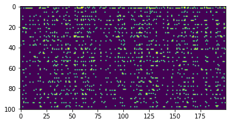

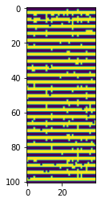

```python
#@title this was with the default parameters
plt.imshow(logger.xs)
plt.show()
plt.imshow(logger.ys)
plt.show()
```

##### Long test

```python
N_E = 200
N_I = 40
T = 10000

logger = Logger(T, N_E, N_I)

SORN(dict(N_E=N_E, N_I=N_I))(T=T, logging_fn=logger.logging_fn)
```

```python
logger.xs.shape
```

```
TensorShape([4634, 200])
```

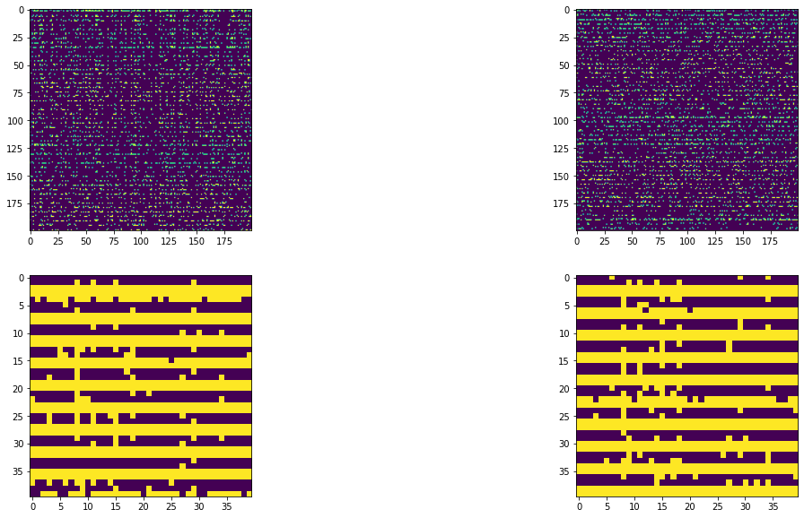

```python
fig, ((axes00, axes01),
      (axes10, axes11)) = plt.subplots(nrows=2, ncols=2,
                                       figsize=(20,10))
axes00.imshow(logger.xs[:200, ...])
axes01.imshow(logger.xs[-200:, ...])
axes10.imshow(logger.ys[:40, ...])
axes11.imshow(logger.ys[-40:, ...])
fig.show()
```

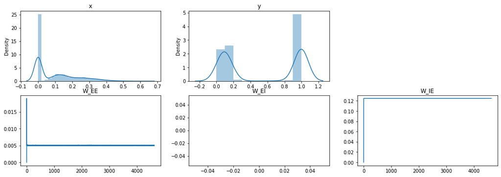

```python
plt.figure(figsize=(18, 6))
plt.title("Means over time")

ax = plt.subplot("231")
ax.set_title("x")
sns.distplot(tf.reduce_mean(logger.xs, axis=-1), ax=ax)

ax = plt.subplot("232")
ax.set_title("y")
sns.distplot(tf.reduce_mean(logger.ys, axis=-1), ax=ax)

ax = plt.subplot("234")
ax.set_title("W_EE")
ax.plot(tf.reduce_mean(logger.W_EEs, axis=[1, 2]))

ax = plt.subplot("235")
ax.set_title("W_EI")
ax.plot(tf.reduce_mean(logger.W_EIs, axis=[1, 2]))

ax = plt.subplot("236")
ax.set_title("W_IE")
ax.plot(tf.reduce_mean(logger.W_IEs, axis=[1, 2]))

plt.show()
```

```python
tf.debugging.assert_all_finite(logger.W_EIs, 'not')
```

[output not shown]

##### Fixed numerical stability problem

```python
N_E = 200
N_I = 40
T = 1000

logger = Logger(T, N_E, N_I)

SORN(dict(N_E=N_E, N_I=N_I))(T=T, logging_fn=logger.logging_fn)
```

```python
tf.debugging.assert_all_finite(logger.W_EEs, 'NaN')
tf.debugging.assert_all_finite(logger.W_EIs, 'NaN')
tf.debugging.assert_all_finite(logger.W_IEs, 'NaN')

logger.xs.shape
```

```
TensorShape([1001, 200])
```

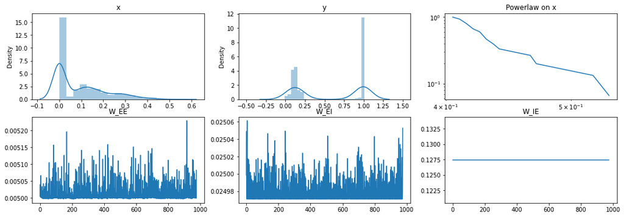

```python
plt.figure(figsize=(18, 6))
plt.title("Means over time")

ax = plt.subplot("231")
ax.set_title("x")
sns.distplot(tf.reduce_mean(logger.xs, axis=-1), ax=ax)

ax = plt.subplot("232")
ax.set_title("y")
sns.distplot(tf.reduce_mean(logger.ys, axis=-1), ax=ax, bins=np.linspace(-0.5, 1.5))

ax = plt.subplot("233")
ax.set_title("Powerlaw on x")
powerlaw.Fit(tf.reduce_mean(logger.xs, axis=-1)).plot_ccdf()

ax = plt.subplot("234")
ax.set_title("W_EE")
ax.plot(tf.reduce_mean(logger.W_EEs[25:, ...], axis=[1, 2]))

ax = plt.subplot("235")
ax.set_title("W_EI")
ax.plot(tf.reduce_mean(logger.W_EIs[25:, ...], axis=[1, 2]))

ax = plt.subplot("236")
ax.set_title("W_IE")
ax.plot(tf.reduce_mean(logger.W_IEs[25:, ...], axis=[1, 2]))


plt.show()
```

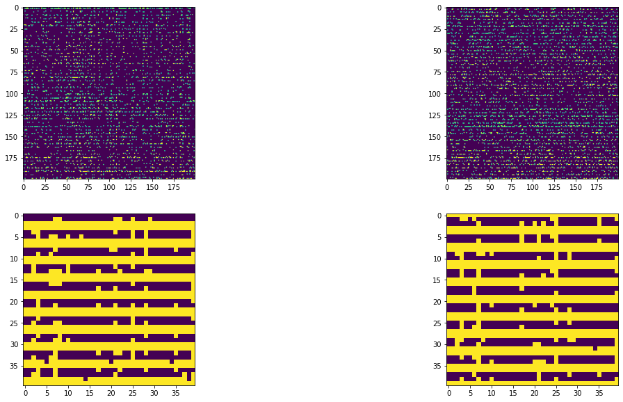

```python
fig, ((axes00, axes01),
      (axes10, axes11)) = plt.subplots(nrows=2, ncols=2,
                                       figsize=(20,10))
axes00.imshow(logger.xs[:200, ...])
axes01.imshow(logger.xs[-200:, ...])
axes10.imshow(logger.ys[:40, ...])
axes11.imshow(logger.ys[-40:, ...])
fig.show()
```

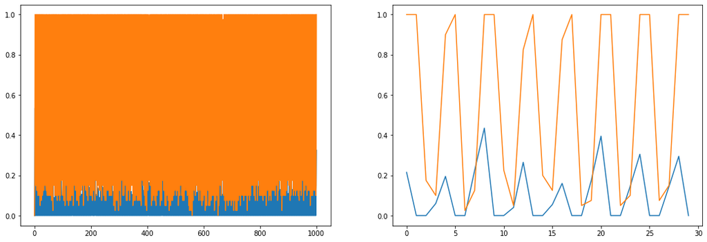

```python
plt.figure(figsize=(18, 6))

ax = plt.subplot("121")
ax.plot(tf.reduce_mean(logger.xs, axis=-1))
ax.plot(tf.reduce_mean(logger.ys, axis=-1))

ax = plt.subplot("122")
ax.plot(tf.reduce_mean(logger.xs[600:630], axis=-1))
ax.plot(tf.reduce_mean(logger.ys[600:630], axis=-1))
```

##### Testing for power laws

```python
xs_mean = tf.reduce_mean(logger.xs, axis=-1)
```

```
Values less than or equal to 0 in data. Throwing out 0 or negative values
Calculating best minimal value for power law fit
```

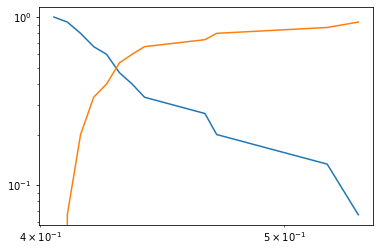

```python
fit = powerlaw.Fit(xs_mean) #([1,3,5,6,3,2,4,7,4,5,21,3,14,24,243,2,2,4,1,11,3,3,5,6])
fit.plot_ccdf()
fit.plot_cdf()
```

#### Testing Machine

```
T=10
```

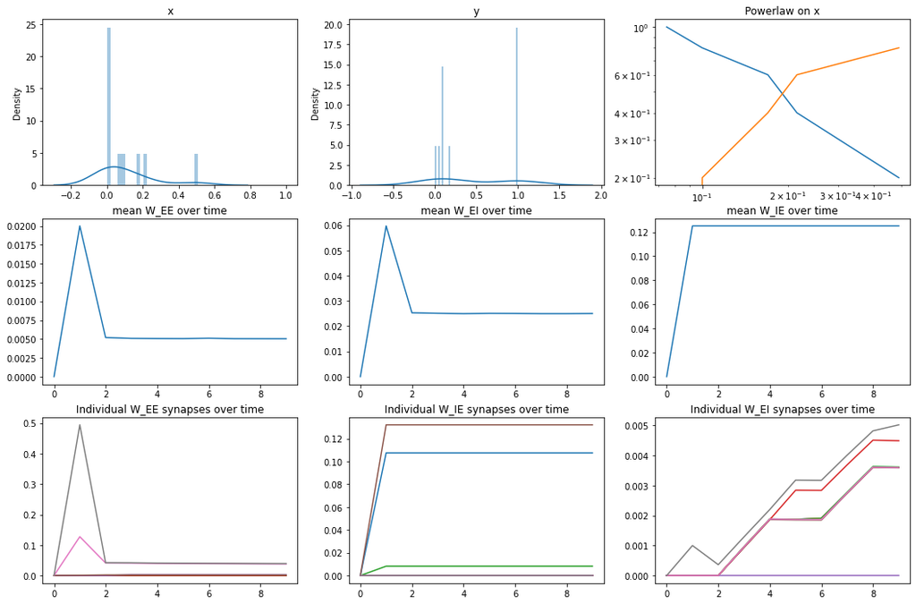

```
================================
T=100
```

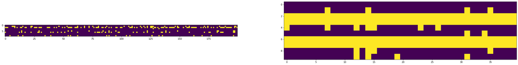

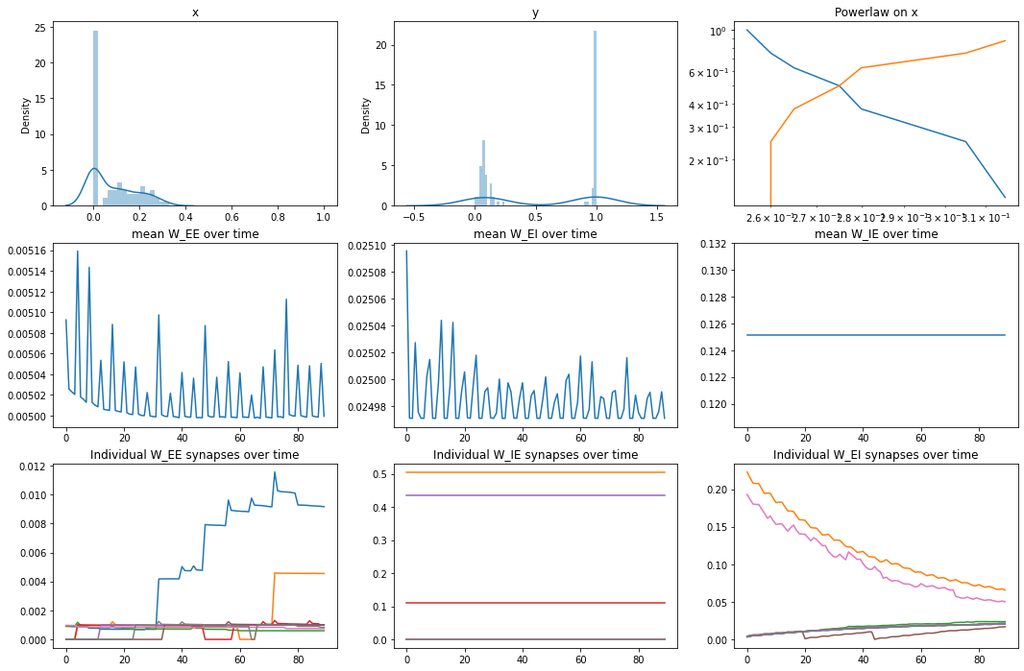

```
================================
T=1000
```

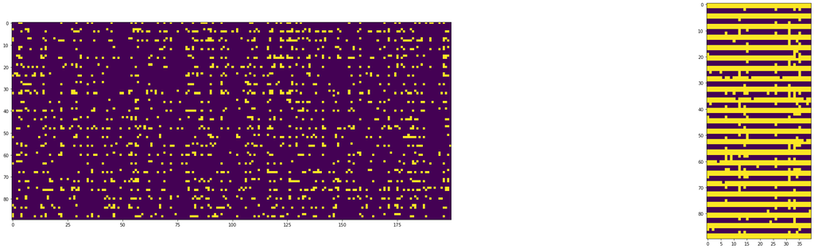

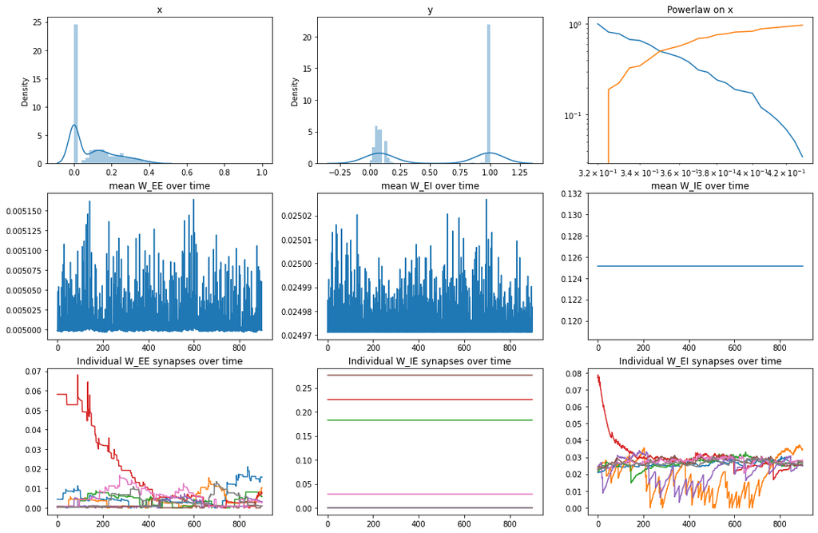

```
================================
T=1500
```

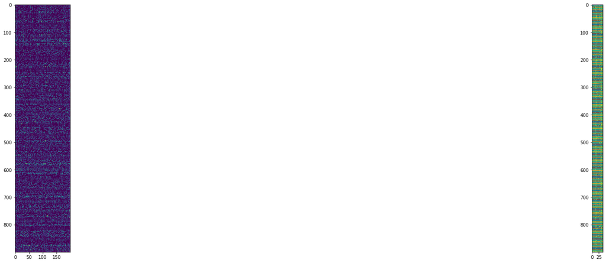

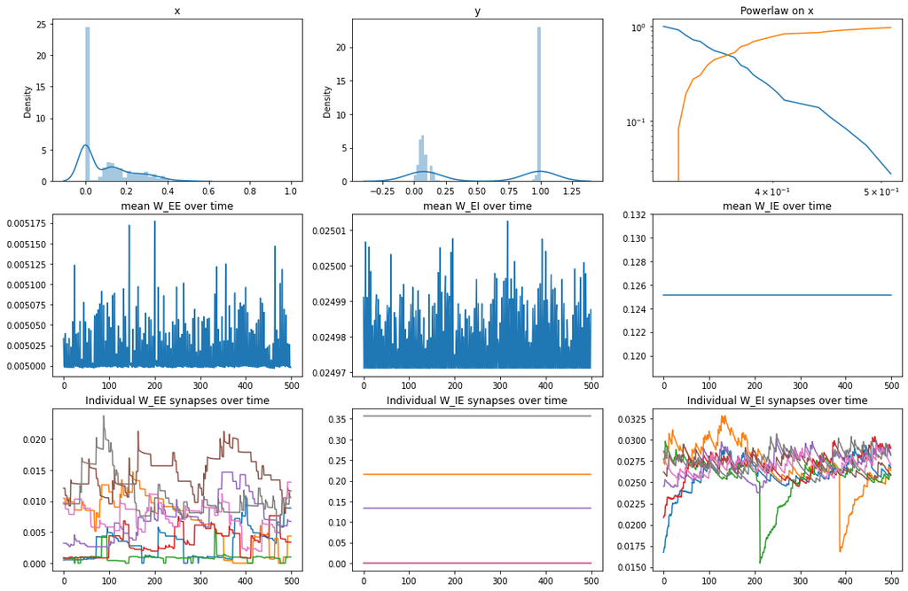

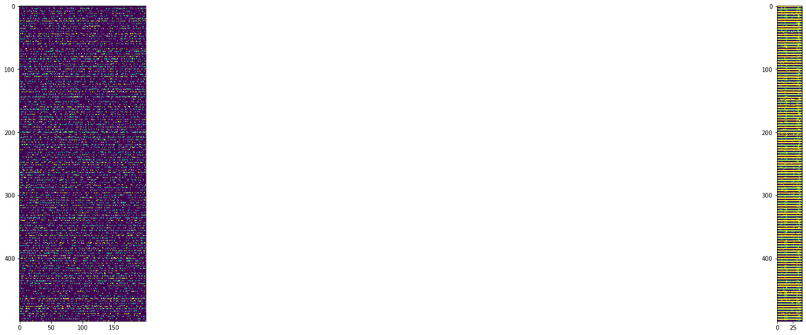

```python
def experiment(control_params, Ts, input_fn):

    logger = Logger(T=Ts[-1],
                    N_E=control_params['N_E'],
                    N_I=control_params['N_I'])
    model = SORN(control_params)

    prev_Ti = 0
    for Ti in Ts:
        print(f"T={Ti}")

        model(inputs=input_fn(Ti-prev_Ti), T=Ti-prev_Ti, logging_fn=logger.logging_fn)

        tf.debugging.assert_all_finite(logger.W_EEs, 'NaN')
        tf.debugging.assert_all_finite(logger.W_EIs, 'NaN')
        tf.debugging.assert_all_finite(logger.W_IEs, 'NaN')

        plt.figure(figsize=(18, 12))
        plt.tight_layout()
        plt.title(f"Simulation for {Ti} steps")

        iv = int(max(1, math.log10(Ti - prev_Ti) / 3))

        ax = plt.subplot("331")
        ax.set_title("x")
        sns.distplot(tf.reduce_mean(logger.xs[prev_Ti:Ti:iv], axis=-1),
                     ax=ax, bins=np.linspace(tf.reduce_min(logger.xs).numpy(),
                                             tf.reduce_max(logger.xs).numpy(),
                                             50))

        ax = plt.subplot("332")
        ax.set_title("y")
        sns.distplot(tf.reduce_mean(logger.ys[prev_Ti:Ti:iv], axis=-1),
                     ax=ax, bins=np.linspace(tf.reduce_min(logger.ys).numpy(),
                                             tf.reduce_max(logger.ys).numpy(),
                                             50))

        ax = plt.subplot("333")
        ax.set_title("Powerlaw on x")
        fit = powerlaw.Fit(tf.reduce_mean(logger.xs[prev_Ti:Ti:iv], axis=-1))
        fit.plot_ccdf()
        fit.plot_cdf()

        ax = plt.subplot("334")
        ax.set_title("mean W_EE over time")
        ax.plot(tf.reduce_mean(logger.W_EEs[prev_Ti:Ti:iv, ...], axis=[1, 2]))

        ax = plt.subplot("335")
        ax.set_title("mean W_EI over time")
        ax.plot(tf.reduce_mean(logger.W_EIs[prev_Ti:Ti:iv, ...], axis=[1, 2]))

        ax = plt.subplot("336")
        ax.set_title("mean W_IE over time")
        ax.plot(tf.reduce_mean(logger.W_IEs[prev_Ti:Ti:iv, ...], axis=[1, 2]))

        ax = plt.subplot("337")
        ax.set_title("Individual W_EE synapses over time")
        W = logger.W_EEs
        for _ in range(8):
            i = random.randint(0, W.shape.as_list()[1]-1)
            j = random.randint(0, W.shape.as_list()[2]-1)
            ax.plot(W.numpy()[prev_Ti:Ti:iv, i, j])
        ax = plt.subplot("338")

        ax.set_title("Individual W_IE synapses over time")
        W = logger.W_IEs
        for _ in range(8):
            i = random.randint(0, W.shape.as_list()[1]-1)
            j = random.randint(0, W.shape.as_list()[2]-1)
            ax.plot(W.numpy()[prev_Ti:Ti:iv, i, j])
        ax = plt.subplot("339")

        ax.set_title("Individual W_EI synapses over time")
        W = logger.W_EIs
        for _ in range(8):
            i = random.randint(0, W.shape.as_list()[1]-1)
            j = random.randint(0, W.shape.as_list()[2]-1)
            ax.plot(W.numpy()[prev_Ti:Ti:iv, i, j])

        plt.show()

        scaley = 40 #min(math.log10(Ti - prev_Ti) * 10, 6) * 10
        scalex = 10 #math.log10(logger.xs.shape[1] + logger.ys.shape[1]) * 2.5
        fig, (axA, axB) = plt.subplots(ncols=2, figsize=(scaley, scalex))
        axA.imshow(logger.xs[prev_Ti:Ti, ::iv])
        axB.imshow(logger.ys[prev_Ti:Ti, ::iv])
        fig.show()

        prev_Ti = Ti
        print(32*'=')

    return logger

logger = experiment(
    control_params=dict(
        N_E = 200,
        N_I = 40,
    ),
    Ts=[10, 100, 1000, 1500],
    input_fn=lambda t : tf.zeros((t, 200)))
```

#### No Input

```
T=10
```

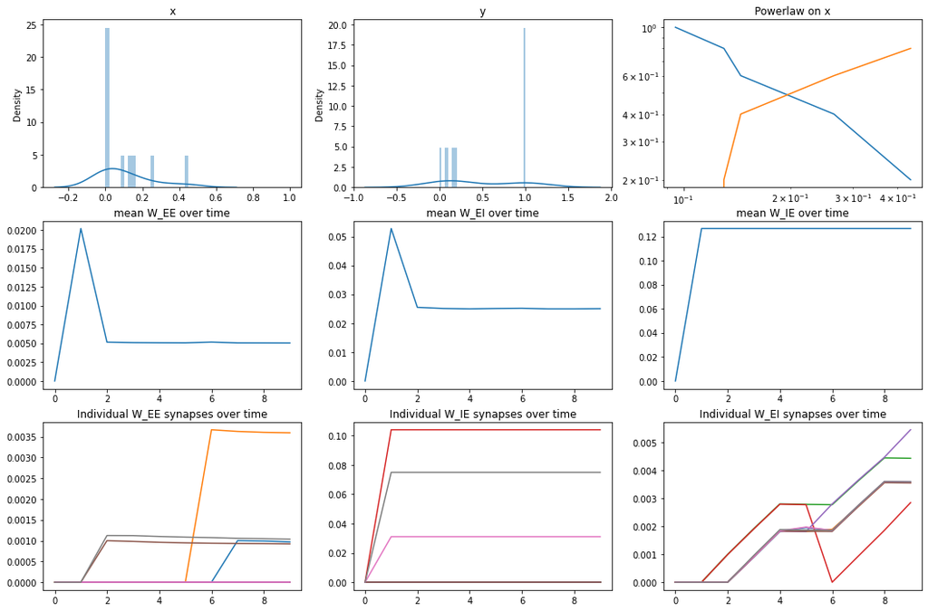

```
================================
T=100
```

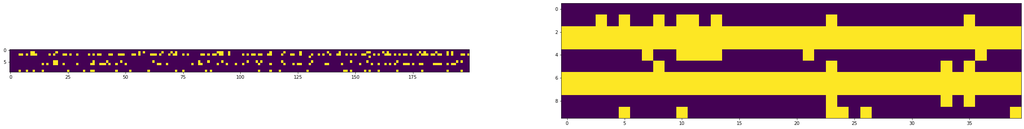

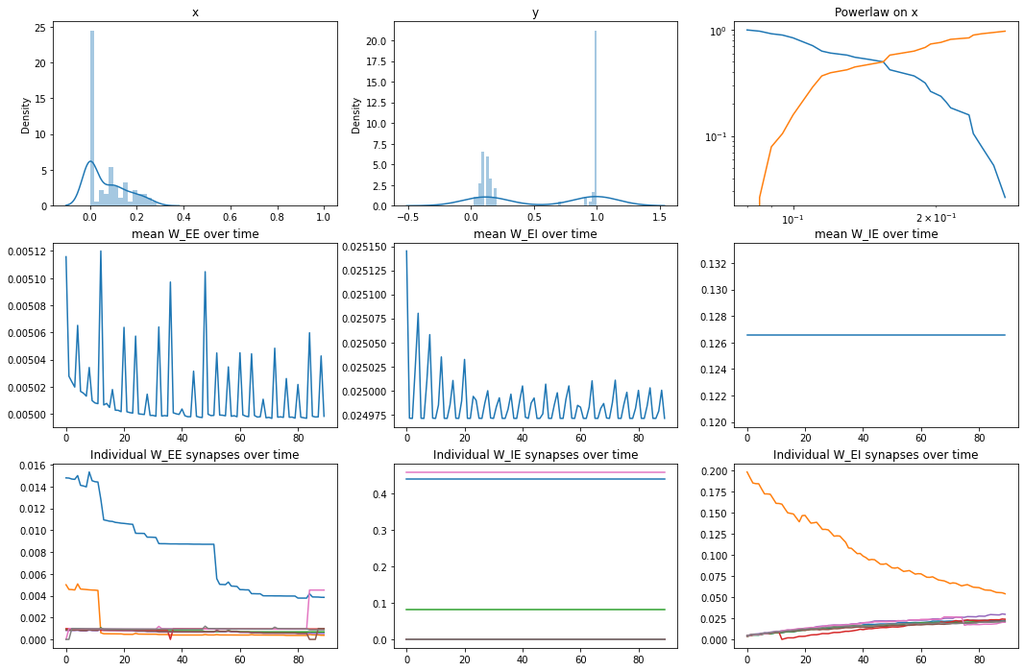

```
================================
T=1000
```

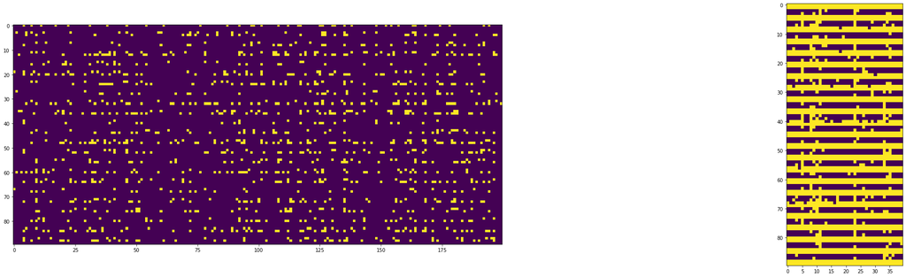

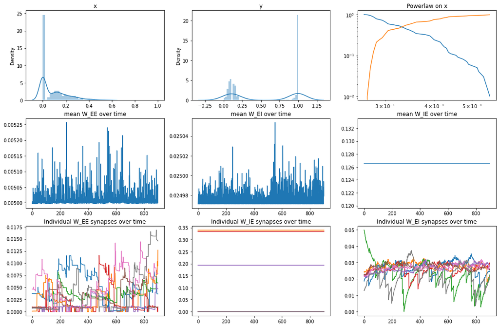

```
================================
T=1500
```

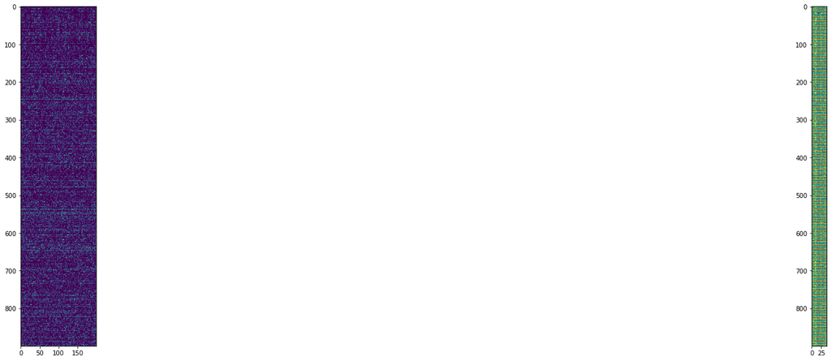

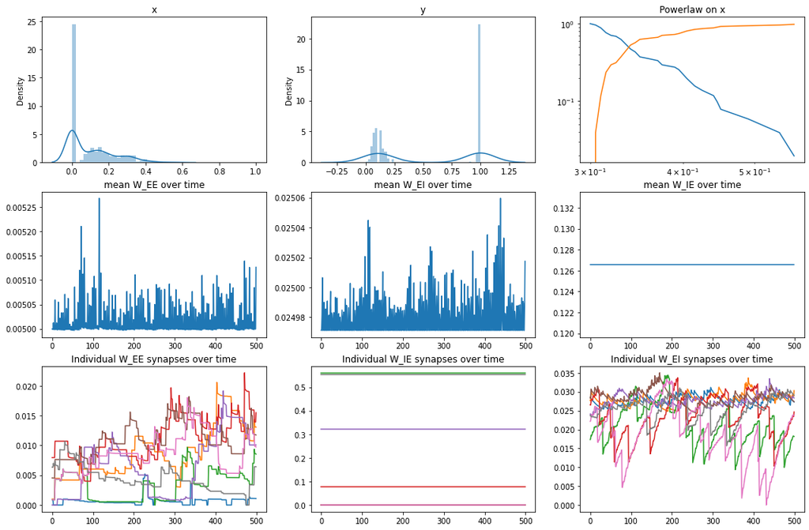

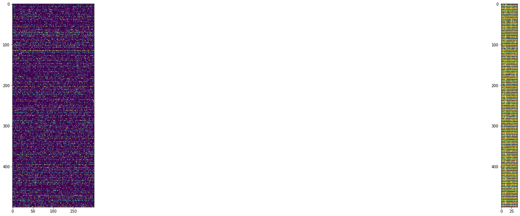

```python
logger = experiment(
    control_params=dict(
        N_E = 200,
        N_I = 40,
    ),
    Ts=[10, 100, 1000, 1500],
    input_fn=lambda t : tf.zeros((t, 200)))
```